# 02_DATA_EDA_V11_504

## 데이터 탐색 전처리 후, 모델 구축

### 학습 목표

- 데이터를 다운로드 후, 데이터 로드부터 시각화, 전처리, 모델 구축의 전과정을 수행해 본다.

### 목차

01. 데이터 불러오기  
02. 데이터 탐색 및 시각화  
03. 특징 선택 및 데이터 나누기  
04. 모델 구축 및 모델 학습 후, 평가  
05. 최종 모델 구축 후, 제출

### 01. 데이터 불러오기

목차로 이동하기

```python
import pandas as pd
import matplotlib.pyplot as plt
import seaborn as sns
import plotly.graph_objs as go
```

```python
train = pd.read_csv("./data/train.csv")
test = pd.read_csv("./data/test.csv")
sub = pd.read_csv("./data/gender_submission.csv")
```

### 02. 데이터 탐색 및 시각화

목차로 이동하기

### Heatmap을 활용한 결측치 확인

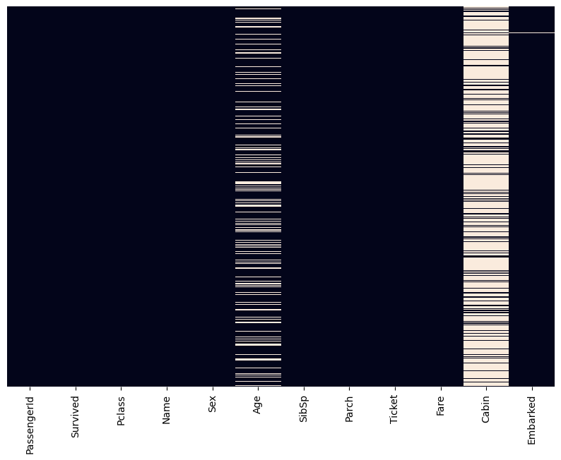

```python
plt.figure(figsize=(10,7))
sns.heatmap(train.isnull(), yticklabels=False, cbar=False)  # cbar : colorbar를 그리지 않음.
```

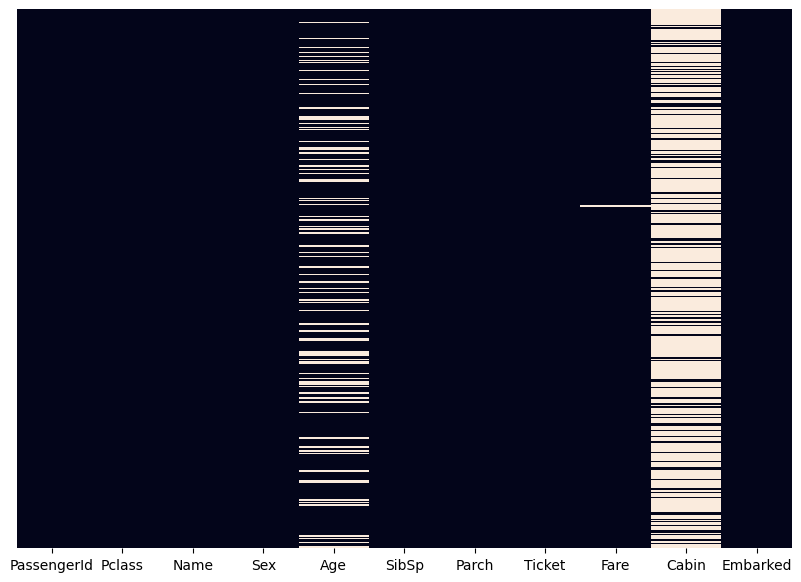

```python
plt.figure(figsize=(10,7))
sns.heatmap(test.isnull(), yticklabels=False, cbar=False)  # cbar : colorbar를 그리지 않음.
```

### 예측하고자 하는 특징(Survived)에 대해 살펴보기

### 생존자와 사망자의 수는 어느정도일까?

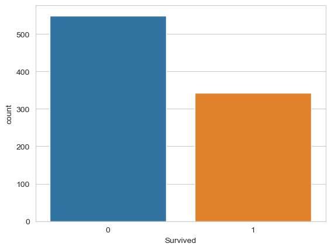

```python
sns.set_style('whitegrid')
sns.countplot(x='Survived', data=train)
```

```python
# 생존자와 사망자 수 계산
survival_counts = train['Survived'].value_counts()

# Plotly 파이 차트 시각화
labels = ['Died', 'Survived']
values = [survival_counts[0], survival_counts[1]]

fig = go.Figure(data=[go.Pie(labels=labels, values=values, hole=0.3,
                             marker=dict(colors=['salmon', 'skyblue']))])

fig.update_layout(title_text='Survival Rates on Titanic', title_x=0.5)
fig.show()
```

[output not shown]

### 성별에 따른 생존자의 비율은 어떻게 될까?

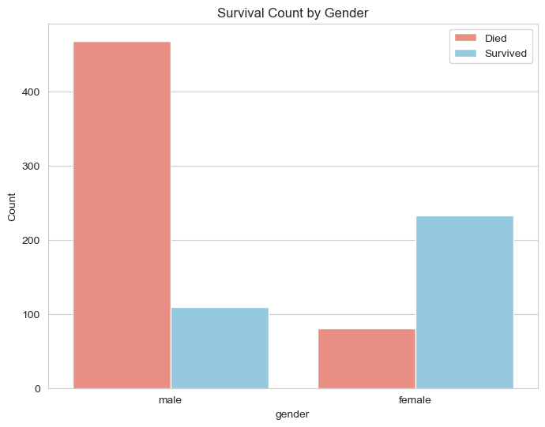

```python
# 성별에 따른 생존율
plt.figure(figsize=(8, 6))
sns.countplot(data=train, x='Sex', hue='Survived', palette=['salmon', 'skyblue'])
plt.title('Survival Count by Gender')
plt.xlabel('gender')
plt.ylabel('Count')
plt.legend(['Died', 'Survived'])
plt.show()
```

### 나이 분포에 따른 생존율은 어떻게 될까?

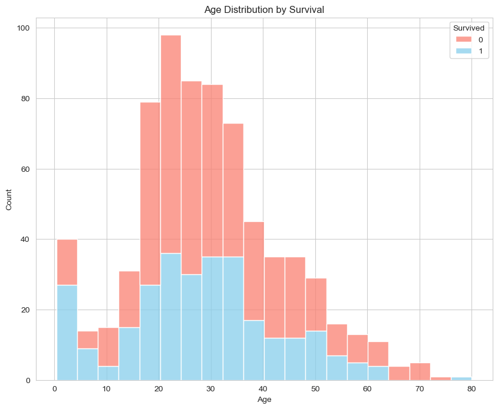

```python
# 나이 분포와 생존율
plt.figure(figsize=(10, 8))
sns.histplot(data=train, x='Age', hue='Survived', multiple='stack', palette=['salmon', 'skyblue'])
plt.title('Age Distribution by Survival')
plt.xlabel('Age')
plt.ylabel('Count')
plt.show()
```

### 객실 등급별에 따른 생존율은 어떠할까?

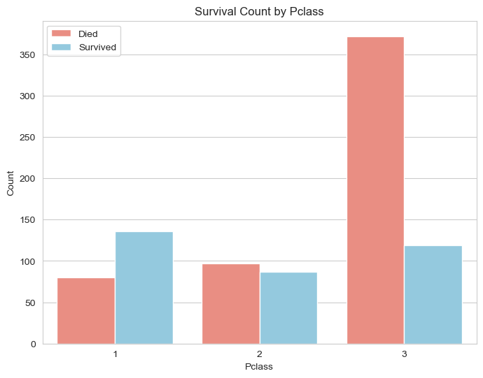

```python
# 객실 등급별 생존율
plt.figure(figsize=(8, 6))
sns.countplot(data=train, x='Pclass', hue='Survived', palette=['salmon', 'skyblue'])
plt.title('Survival Count by Pclass')
plt.xlabel('Pclass')
plt.ylabel('Count')
plt.legend(['Died', 'Survived'])
plt.show()
```

### 승선 항구별 생존율은 어떠할까?

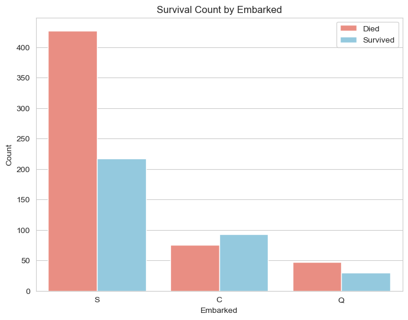

```python
# 승선 항구별 생존율
plt.figure(figsize=(8, 6))
sns.countplot(data=train, x='Embarked', hue='Survived', palette=['salmon', 'skyblue'])
plt.title('Survival Count by Embarked')
plt.xlabel('Embarked')
plt.ylabel('Count')
plt.legend(['Died', 'Survived'])
plt.show()
```

### 가족 구성에 따른 생존율은 어떠할까?

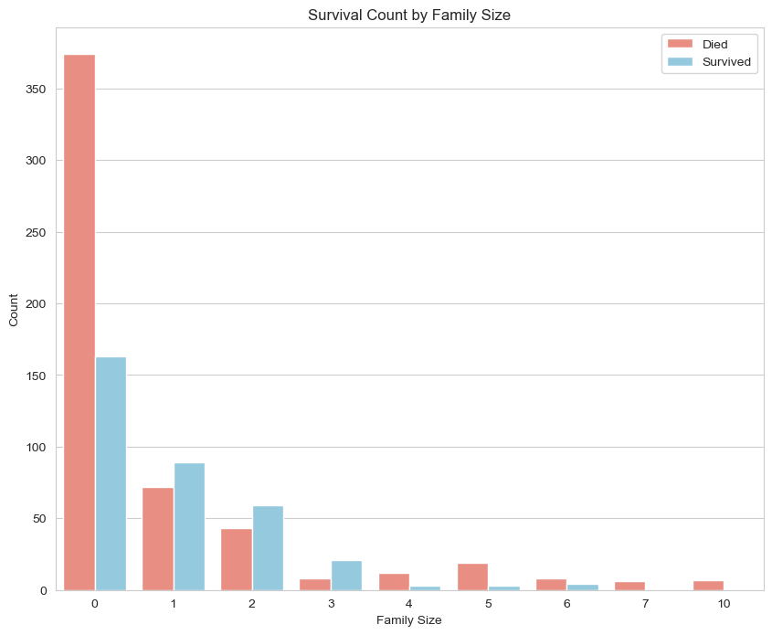

```python
# 가족 구성 여부에 따른 생존율
train['FamilySize'] = train['SibSp'] + train['Parch']
plt.figure(figsize=(10, 8))
sns.countplot(data=train, x='FamilySize', hue='Survived', palette=['salmon', 'skyblue'])
plt.title('Survival Count by Family Size')
plt.xlabel('Family Size')
plt.ylabel('Count')
plt.legend(['Died', 'Survived'])
plt.show()
```

### 학습용(train), 테스트용(test)의 나이대 분포를 살펴보자.

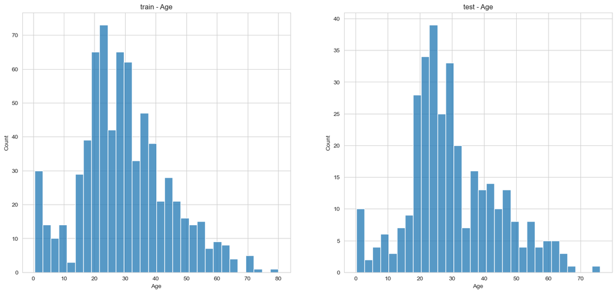

```python
f,ax=plt.subplots(1,2,figsize=(18,8))

# 첫번째 그래프
sns.histplot(train['Age'].dropna(), bins=30,ax=ax[0])
ax[0].set_title('train - Age')

# 두번째 그래프
sns.histplot(test['Age'].dropna(), bins=30,ax=ax[1])
ax[1].set_title('test - Age')
plt.show()
```

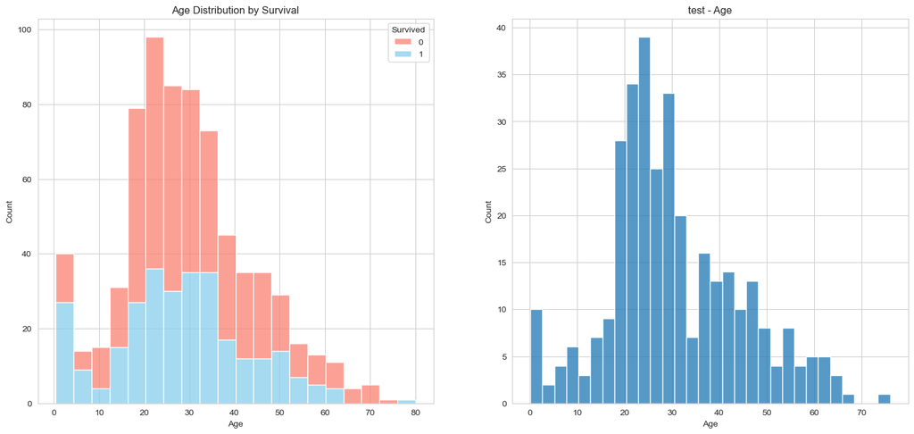

```python
f,ax=plt.subplots(1,2,figsize=(18,8))

# 첫번째 그래프
plt.figure(figsize=(10, 8))
sns.histplot(data=train, x='Age', hue='Survived', multiple='stack', palette=['salmon', 'skyblue'],ax=ax[0])
ax[0].set_title('Age Distribution by Survival')
ax[0].set_xlabel('Age')
ax[0].set_ylabel('Count')


# 두번째 그래프
sns.histplot(test['Age'].dropna(), bins=30,ax=ax[1])
ax[1].set_title('test - Age')
plt.show()
```

### 데이터 전처리 후, 모델에 해당 특징을 추가해 보자.

### 03. 데이터 전처리

목차로 이동하기

### Age(나이)에 대한 데이터 전처리

```python
train['Age'] = train['Age'].fillna(train['Age'].mean())
test['Age'] = test['Age'].fillna(test['Age'].mean())
```

```python
print(train.isnull().sum())
print(test.isnull().sum())
```

```
PassengerId      0
Survived         0
Pclass           0
Name             0
Sex              0
Age              0
SibSp            0
Parch            0
Ticket           0
Fare             0
Cabin          687
Embarked         2
FamilySize       0
dtype: int64
PassengerId      0
Pclass           0
Name             0
Sex              0
Age              0
SibSp            0
Parch            0
Ticket           0
Fare             1
Cabin          327
Embarked         0
dtype: int64
```

### Embarked(승선항)에 대한 결측치 전처리

```python
val_Embarked = train['Embarked'].value_counts()
val_Embarked
```

[output not shown]

- 승선항이 많은 값으로 결측치 처리를 수행한다.

```python
train['Embarked'] = train['Embarked'].fillna('S')
```

### Fare(요금)에 대한 결측치 처리

- 특징을 선택해서 사용해야 한다면, test 데이터 셋은 반드시 결측치 처리 후, 사용해야 한다.

```python
test['Fare'] = test['Fare'].fillna(test['Fare'].mean())
```

### FamilySize 특징 추가

```python
# 가족 구성 여부에 따른 생존율
train['FamilySize'] = train['SibSp'] + train['Parch']
test['FamilySize'] = test['SibSp'] + test['Parch']
```

```python
print(train.isnull().sum())
print(test.isnull().sum())
```

```
PassengerId      0
Survived         0
Pclass           0
Name             0
Sex              0
Age              0
SibSp            0
Parch            0
Ticket           0
Fare             0
Cabin          687
Embarked         0
FamilySize       0
dtype: int64
PassengerId      0
Pclass           0
Name             0
Sex              0
Age              0
SibSp            0
Parch            0
Ticket           0
Fare             0
Cabin          327
Embarked         0
FamilySize       0
dtype: int64
```

### 성별에 대한 데이터 전처리 후, 모델에 사용

- 레이블 인코딩(Label Encoding) : 범주형 데이터를 수치형 데이터로 변환하는 과정입니다. 범주형 데이터는 고유한 값(예: 문자열 또는 범주)으로 이루어진 데이터이며, 이를 모델에 직접 입력할 수 없기 때문에 수치형 데이터로 변환해야 한다.

```python
print( train['Sex'].value_counts() )
print( train['Embarked'].value_counts() )
```

```
Sex
male      577
female    314
Name: count, dtype: int64
Embarked
S    646
C    168
Q     77
Name: count, dtype: int64
```

### pandas의 map함수를 이용하여 레이블 인코딩

```python
train['Sex'] = train['Sex'].map( {'female': 0, 'male': 1} ).astype(int)
test['Sex'] = test['Sex'].map( {'female': 0, 'male': 1} ).astype(int)

train['Embarked'] = train['Embarked'].map( {'S': 0, 'C': 1, 'Q': 2} ).astype(int)
test['Embarked']= test['Embarked'].map( {'S': 0, 'C': 1, 'Q': 2} ).astype(int)
```

```python
## 나이에 대한 int 처리
train['Age'] = train['Age'].astype('int')
test['Age'] = test['Age'].astype('int')
```

```python
print(train.columns)
print(train.info())
print()
print(test.info())
```

```
Index(['PassengerId', 'Survived', 'Pclass', 'Name', 'Sex', 'Age', 'SibSp',
       'Parch', 'Ticket', 'Fare', 'Cabin', 'Embarked', 'FamilySize'],
      dtype='object')
<class 'pandas.core.frame.DataFrame'>
RangeIndex: 891 entries, 0 to 890
Data columns (total 13 columns):
 #   Column       Non-Null Count  Dtype
---  ------       --------------  -----
 0   PassengerId  891 non-null    int64
 1   Survived     891 non-null    int64
 2   Pclass       891 non-null    int64
 3   Name         891 non-null    object
 4   Sex          891 non-null    int32
 5   Age          891 non-null    int32
 6   SibSp        891 non-null    int64
 7   Parch        891 non-null    int64
 8   Ticket       891 non-null    object
 9   Fare         891 non-null    float64
 10  Cabin        204 non-null    object
 11  Embarked     891 non-null    int32
 12  FamilySize   891 non-null    int64
dtypes: float64(1), int32(3), int64(6), object(3)
memory usage: 80.2+ KB
None

<class 'pandas.core.frame.DataFrame'>
RangeIndex: 418 entries, 0 to 417
Data columns (total 12 columns):
 #   Column       Non-Null Count  Dtype
---  ------       --------------  -----
 0   PassengerId  418 non-null    int64
 1   Pclass       418 non-null    int64
 2   Name         418 non-null    object
 3   Sex          418 non-null    int32
 4   Age          418 non-null    int32
 5   SibSp        418 non-null    int64
 6   Parch        418 non-null    int64
 7   Ticket       418 non-null    object
 8   Fare         418 non-null    float64
 9   Cabin        91 non-null     object
 10  Embarked     418 non-null    int32
 11  FamilySize   418 non-null    int64
dtypes: float64(1), int32(3), int64(5), object(3)
memory usage: 34.4+ KB
None
```

### 03. 특징 선택 및 데이터 나누기

목차로 이동하기

### 특징 간의 관계 확인을 위해 상관계수 확인

```python
# 사용할 특징과 예측할 타겟. 상관계수 확인
sel_XY = ['PassengerId', 'Pclass', 'Sex', 'Age', 'SibSp', 'FamilySize','Parch', 'Embarked', 'Survived']
train_all = train[sel_XY]
print( train_all.columns )
corr_XY = train_all.corr()
corr_XY
```

```
Index(['PassengerId', 'Pclass', 'Sex', 'Age', 'SibSp', 'FamilySize', 'Parch',
       'Embarked', 'Survived'],
      dtype='object')
```

|  | PassengerId | Pclass | Sex | Age | SibSp | FamilySize | Parch | Embarked | Survived |
| --- | --- | --- | --- | --- | --- | --- | --- | --- | --- |
| PassengerId | 1.000000 | -0.035144 | 0.042939 | 0.033741 | -0.057527 | -0.040143 | -0.001652 | -0.030467 | -0.005007 |
| Pclass | -0.035144 | 1.000000 | 0.131900 | -0.335071 | 0.083081 | 0.065997 | 0.018443 | 0.045702 | -0.338481 |
| Sex | 0.042939 | 0.131900 | 1.000000 | 0.082533 | -0.114631 | -0.200988 | -0.245489 | -0.116569 | -0.543351 |
| Age | 0.033741 | -0.335071 | 0.082533 | 1.000000 | -0.232743 | -0.247370 | -0.176744 | 0.000234 | -0.067809 |
| SibSp | -0.057527 | 0.083081 | -0.114631 | -0.232743 | 1.000000 | 0.890712 | 0.414838 | -0.059961 | -0.035322 |
| FamilySize | -0.040143 | 0.065997 | -0.200988 | -0.247370 | 0.890712 | 1.000000 | 0.783111 | -0.080281 | 0.016639 |
| Parch | -0.001652 | 0.018443 | -0.245489 | -0.176744 | 0.414838 | 0.783111 | 1.000000 | -0.078665 | 0.081629 |
| Embarked | -0.030467 | 0.045702 | -0.116569 | 0.000234 | -0.059961 | -0.080281 | -0.078665 | 1.000000 | 0.106811 |
| Survived | -0.005007 | -0.338481 | -0.543351 | -0.067809 | -0.035322 | 0.016639 | 0.081629 | 0.106811 | 1.000000 |

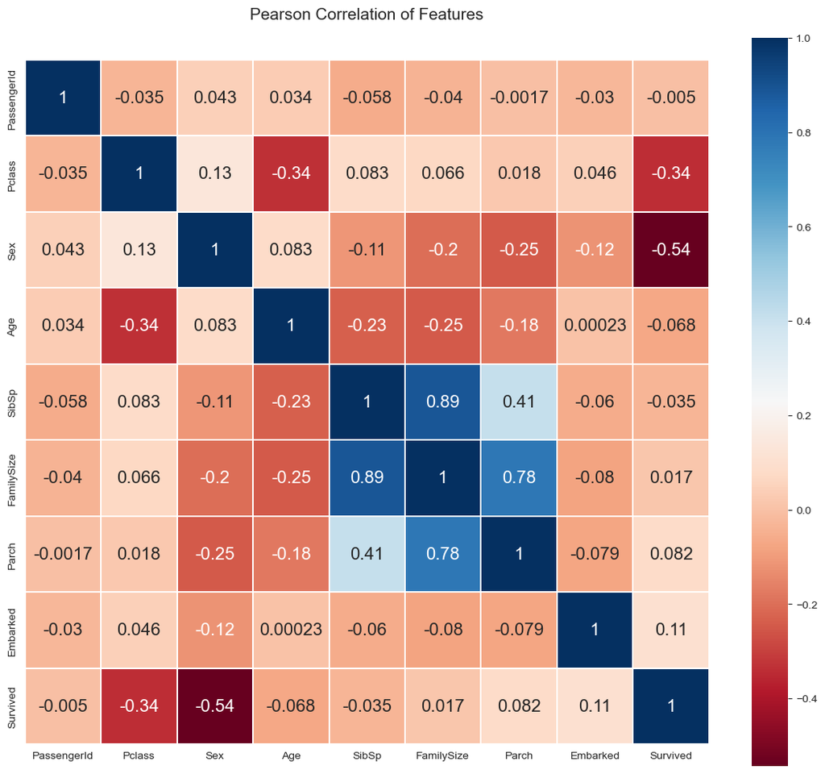

```python
colormap = plt.cm.RdBu
plt.figure(figsize=(14, 12))
plt.title('Pearson Correlation of Features', y=1.05, size=15)
sns.heatmap(corr_XY, linewidths=0.1, vmax=1.0,
           square=True, cmap=colormap, linecolor='white', annot=True, annot_kws={"size": 16})
```

```python
from sklearn.model_selection import train_test_split
```

```python
# 'Name', 'Ticket' =>  문자포함
sel = ['PassengerId', 'Pclass', 'Sex', 'Age', 'SibSp', 'FamilySize','Parch', 'Embarked' ]

# 학습에 사용될 데이터 준비 X_train, y_train
X_train_all = train[sel]
y_train_all = train['Survived']
```

```python
# 데이터를 학습 세트와 테스트 세트로 분할  train(70%), test(30%)
X_train, X_test, y_train, y_test = train_test_split(X_train_all, y_train_all,
                                                    test_size=0.3, random_state=42)

# 분할된 데이터 출력
print("X_train shape:", X_train.shape)
print("X_test shape:", X_test.shape)
print("y_train shape:", y_train.shape)
print("y_test shape:", y_test.shape)
```

```
X_train shape: (623, 8)
X_test shape: (268, 8)
y_train shape: (623,)
y_test shape: (268,)
```

```python
# 최종 예측을 위한 test 데이터
X_test_last = test[sel]
```

### 04. 모델 구축 및 학습, 이후 모델 평가

목차로 이동하기

```python
from sklearn.neighbors import KNeighborsClassifier

# 모델 구축 및 학습
model = KNeighborsClassifier()
model.fit(X_train, y_train)
pred = model.predict(X_test)
pred
```

```
array([0, 1, 0, 0, 0, 0, 0, 1, 1, 0, 0, 0, 0, 0, 0, 0, 0, 0, 0, 0, 0, 0,
       0, 0, 1, 0, 0, 0, 0, 0, 0, 0, 0, 0, 0, 0, 1, 0, 0, 0, 0, 0, 1, 0,
       1, 0, 0, 1, 0, 0, 1, 0, 0, 0, 1, 0, 0, 0, 0, 0, 0, 1, 0, 0, 0, 0,
       0, 0, 1, 0, 1, 1, 0, 1, 0, 0, 0, 1, 0, 0, 1, 0, 1, 0, 0, 0, 0, 0,
       0, 0, 0, 1, 1, 1, 0, 0, 0, 0, 1, 1, 1, 0, 0, 0, 0, 1, 0, 1, 0, 0,
       0, 0, 0, 1, 0, 0, 0, 0, 1, 1, 0, 0, 0, 0, 0, 0, 0, 0, 1, 0, 0, 0,
       0, 1, 0, 0, 1, 0, 1, 0, 0, 1, 0, 0, 0, 0, 0, 1, 1, 0, 0, 0, 0, 0,
       0, 0, 0, 0, 0, 0, 0, 1, 0, 1, 1, 0, 0, 0, 0, 1, 0, 0, 1, 0, 1, 0,
       0, 0, 0, 1, 0, 1, 0, 0, 0, 1, 1, 1, 1, 1, 0, 1, 0, 0, 0, 0, 0, 0,
       0, 1, 0, 1, 1, 0, 0, 1, 0, 1, 0, 0, 0, 1, 0, 0, 0, 0, 1, 0, 0, 0,
       0, 0, 0, 0, 0, 0, 0, 0, 1, 0, 0, 0, 1, 1, 0, 0, 0, 0, 1, 1, 1, 1,
       0, 0, 0, 0, 0, 0, 1, 1, 0, 0, 0, 0, 0, 0, 0, 1, 0, 0, 0, 1, 0, 0,
       0, 1, 0, 1], dtype=int64)
```

```python
from sklearn.metrics import accuracy_score, confusion_matrix, classification_report
```

```python
# 정확도 계산
accuracy = accuracy_score(y_test, pred)
print(f'Accuracy: {accuracy:.2f}')
```

```
Accuracy: 0.55
```

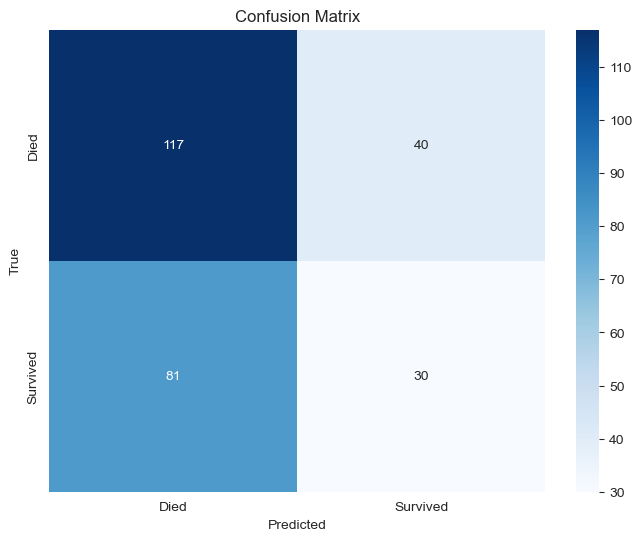

```python
# 혼동 행렬 계산 및 시각화
conf_matrix = confusion_matrix(y_test, pred)
plt.figure(figsize=(8, 6))
sns.heatmap(conf_matrix, annot=True,
            fmt='d', cmap='Blues', xticklabels=['Died', 'Survived'], yticklabels=['Died', 'Survived'])

plt.xlabel('Predicted')
plt.ylabel('True')
plt.title('Confusion Matrix')
plt.show()
```

### 좀 더 좋은 모델을 사용해 보자.

```python
from sklearn.tree import DecisionTreeClassifier
from sklearn.ensemble import RandomForestClassifier
from sklearn.linear_model import LogisticRegression

from sklearn.metrics import accuracy_score, precision_score, recall_score, f1_score
```

```python
# 모델 리스트
models = {
    "KNN": KNeighborsClassifier(n_neighbors=5),
    "Random Forest": RandomForestClassifier(n_estimators=100, random_state=42),
    "Logistic Regression": LogisticRegression()
}
```

```python
# 결과 저장을 위한 리스트
results = []

# 각 모델에 대해 학습, 예측 및 평가 수행
for name, model in models.items():
    model.fit(X_train, y_train)
    y_pred = model.predict(X_test)
    accuracy = accuracy_score(y_test, y_pred)
    precision = precision_score(y_test, y_pred)
    recall = recall_score(y_test, y_pred)
    f1 = f1_score(y_test, y_pred)
    results.append([name, accuracy, precision, recall, f1])

# 결과 데이터프레임 생성
results_df = pd.DataFrame(results, columns=['Model', 'Accuracy', 'Precision', 'Recall', 'F1 Score'])
print(results_df)
```

```
                 Model  Accuracy  Precision    Recall  F1 Score
0                  KNN  0.548507   0.428571  0.270270  0.331492
1        Random Forest  0.802239   0.822222  0.666667  0.736318
2  Logistic Regression  0.798507   0.800000  0.684685  0.737864
```

### 참고를 위한 설명 - 분류 모델에 대한 평가 지표

- accuracy(정확도) : 정확도는 모델이 올바르게 예측한 비율을 나타냅니다. 전체 예측 중에서 얼마나 많은 예측이 정확했는지.
  - 계산 방법: (정확하게 예측한 샘플 수) / (전체 샘플 수)
  - 100개의 샘플 중 90개를 정확히 예측했다면 정확도는 90%입니다.
- precision(정밀도) : 정밀도는 모델이 양성(positive)이라고 예측한 것들 중에서 실제로 양성인 것의 비율을 나타냅니다. 즉, 양성 예측의 정확성.
  - 계산 방법: (정확히 양성으로 예측한 샘플 수) / (양성으로 예측한 전체 샘플 수)
  - 예를 들어, 모델이 10개를 양성으로 예측했는데 그 중 7개가 실제로 양성이라면, 정밀도는 70%입니다.
- recall(재현율) : 재현율은 실제 양성인 것들 중에서 모델이 얼마나 많은 양성을 올바르게 예측했는지를 나타냅니다. 즉, 실제 양성을 얼마나 잘 찾아냈는지 보여준다.
  - 계산 방법: (정확히 양성으로 예측한 샘플 수) / (전체 실제 양성 샘플 수)
  - 예를 들어, 실제로 20개의 양성이 있는데 모델이 그 중 15개를 양성으로 예측했다면, 재현율은 75%입니다.
- f1 score : F1점수
  - 계산 방법: 2 *(정밀도* 재현율) / (정밀도 + 재현율)
  - F1 점수는 정밀도와 재현율을 모두 고려하기 때문에, 특히 불균형 데이터셋(예: 긍정 샘플이 매우 적은 경우)에서 유용함.

### 05. 최종 모델 구축 후, 제출

목차로 이동하기

```python
from sklearn.ensemble import RandomForestClassifier

# 모델 구축
model = RandomForestClassifier()

# 학습
model.fit(X_train_all, y_train_all)

# 예측
y_pred = model.predict(X_test_last)

sub['Survived'] = y_pred
sub.head()
```

|  | PassengerId | Survived |
| --- | --- | --- |
| 0 | 892 | 0 |
| 1 | 893 | 0 |
| 2 | 894 | 0 |
| 3 | 895 | 0 |
| 4 | 896 | 0 |

```python
sub.to_csv("second_rf_model.csv", index=False)
```

### 제출 결과 확인

- Baseline 모델
  - knn 0.6220
  - Random Forest - 0.77033